# A Practical Roadmap for Whole-Exome Sequencing Data Analysis

# A Practical Roadmap for Whole-Exome Sequencing Data Analysis

Jiahao Ma (`jiahaoma@stu.pku.edu.cn`), Zexian Zeng (`zexianzeng@pku.edu.cn`)

Center of Life Sciences & Center for Quantitative Biology

Academy for Advanced Interdisciplinary Studies, Peking University, Beijing, China

Thanks to Yufeng He for his previous work on teaching roadmap.

[Lab website](https://cqb.pku.edu.cn/zenglab)

> Today, we celebrate the revelation of the first draft of the human book of life.  
> — Francis Collins

## 0. Environment, conventions and our roadmap

> “工欲善其事，必先利其器。”  
> ——《论语·卫灵公》

### 0.1 Required tools

| Tool | Main purpose |
| --- | --- |
| `fastp` | Read trimming, adapter removal, per-base quality filtering, QC report |
| `bwa` | Alignment of reads to a reference genome |
| `samtools` | SAM/BAM conversion, sorting, indexing, coverage and flag statistics |
| `bcftools` | VCF viewing, filtering, compression and indexing |
| `GATK4` | Duplicate marking, BQSR, germline and somatic variant calling, VQSR |
| `ANNOVAR` | Functional annotation of variants |
| `CNVkit` | Copy-number variation detection from targeted sequencing data |

```bash
ssh CCIPKUHPC_node03
```

Add the shared Miniconda initialization and workflow variables to `/gpfs1/home/$USER/.bashrc`:

```bash
cat >> ~/.bashrc <<'EOF'

# WES teaching-cluster initialization
export SHARE=/lustre1/share
export MINICONDA=$SHARE/miniconda3
source "$MINICONDA/etc/profile.d/conda.sh"
EOF

source ~/.bashrc
conda activate wes
```

Then add the following variables to your current shell:

```bash
export SHARE=/lustre1/share
export REF=$SHARE/references
export TARGETS=$REF/S07604514_AllTracks_V6_60_hg38.bed
export REFERENCE=$REF/hg38.fa
export DBSNP=$REF/dbsnp_138.hg38.vcf
export INDELS=$REF/Mills_and_1000G_gold_standard.indels.hg38.vcf
export HIGHCONF=$REF/1000G_phase1.snps.high_confidence.hg38.vcf
export HAPMAP=$REF/hapmap_3.3.hg38.vcf
export OMNI=$REF/1000G_omni2.5.hg38.vcf
export ANNOVAR=$SHARE/annovar_new
export HUMANDB=$ANNOVAR/humandb
export PATH=$ANNOVAR:$PATH
export DATA=$SHARE/data_new
export BASE=/lustre1/user/$USER/wes_run_cluster_$(date +%Y%m%d) # Caution: if you want to continue the previous run, please change this to exact previous run path, e.g., /gpfs1/home/$USER/wes_run_cluster_20260911
export OUT=$BASE
```

Attention: If you want to run the analysis in a new shell (e.g., a new ssh terminal), you need to export these variables again.

The required executables are provided by the shared environment, you can run the following commands to check the versions:

```bash
fastp --version
bwa 2>&1 | head -n 3
samtools --version | head -n 1
bcftools --version | head -n 1
gatk --version
cnvkit.py version
table_annovar.pl --version
```

### 0.2 Directory convention

The examples use the following directories. Each student writes under their own home directory and reads shared data and references:

```bash
mkdir -p "$OUT"/{0_fastq,1_alignment/OC,1_alignment/PBMC,2_variant_call,3_annotation,4_cnv,5_somatic_tmb}
mkdir -p "$OUT"/{log,resources}
```

```bash
ln -s "$DATA/OC/OC_R1.fq.gz" "$OUT/0_fastq/OC_R1.fq.gz"
ln -s "$DATA/OC/OC_R2.fq.gz" "$OUT/0_fastq/OC_R2.fq.gz"
ln -s "$DATA/PBMC/blood_R1.fq.gz" "$OUT/0_fastq/PBMC_R1.fq.gz"
ln -s "$DATA/PBMC/blood_R2.fq.gz" "$OUT/0_fastq/PBMC_R2.fq.gz"
```

```bash
ANNOVAR=/lustre1/share/annovar/annovar
HUMANDB=$ANNOVAR/humandb
```

The two example samples are:

```
OC:    ovarian-cancer tissue sample, treated as the tumor sample
PBMC:  matched blood sample, treated as the normal sample
```

### 0.3 Reference genome

Use a single consistent genome build throughout the workflow. The shared teaching references use GRCh38/hg38:

```
$REF/hg38.fa
$REF/hg38.dict
$REF/hg38.fa.fai
```

GATK also requires a sequence dictionary. They are already present in the shared reference directory, so verify rather than regenerate them:

```bash
ls -lh "$REFERENCE"{,.fai,.amb,.ann,.bwt,.pac,.sa} "$REF/hg38.dict"
```

### 0.4 Roadmap

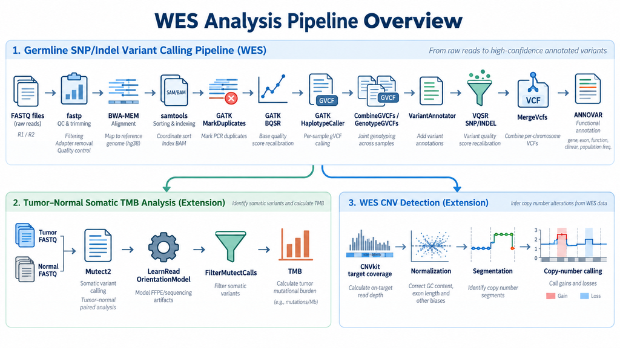

## 1. FASTQ files

FASTQ stores biological sequence plus a per-base quality score. A paired-end read is stored in two files, usually named `R1` and `R2`. Each sequence occupies four lines:

```
@instrument:run:flowcell:lane:tile:x:y read1:N:0:INDEX1+INDEX2
ACGTACGTACGT...
+
IIIIIHHHHFFFF...
```

The first line is the read identifier. The second line is the nucleotide sequence. The third line is a separator. The fourth line contains Phred quality scores encoded as ASCII characters.

The Phred score is:

```
Q = -10 * log10(P_error)
P_error = 10^(-Q/10)
```

Examples:

| Phred score | Probability of error | Accuracy |
| --- | --- | --- |
| Q10 | 0.1 | 90% |
| Q20 | 0.01 | 99% |
| Q30 | 0.001 | 99.9% |
| Q40 | 0.0001 | 99.99% |

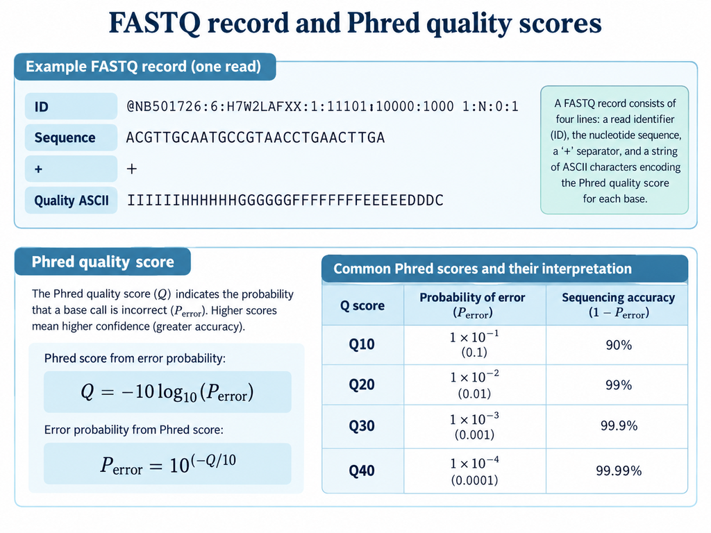

### 1.1 Inspect FASTQ

View the first eight lines:

```bash
zcat $OUT/0_fastq/OC_R1.fq.gz | head -n 8
```

Count reads in a FASTQ file:

```bash
zcat $OUT/0_fastq/OC_R1.fq.gz | awk 'END {print NR/4}'
```

## 2. Read quality control with fastp

> "The first principle is that you must not fool yourself—and you are the easiest person to fool."  
> — Richard Feynman

Raw reads may contain adapters, low-quality tails, poly-G artifacts, and very short fragments. `fastp` removes these problematic reads or bases and produces HTML/JSON QC reports.

The algorithmic logic is:

1. Detect adapters from overlapping read pairs or known adapter sequences.
2. Trim low-quality bases from read ends.
3. Remove reads that are too short after trimming.
4. Summarize per-base quality, GC content, adapter contamination, duplication, and insertion-size distributions.

### 2.1 Create QC output directories

```bash
mkdir -p "$OUT/0_fastq/OC" "$OUT/0_fastq/PBMC"
```

### 2.2 Run fastp

For OC:

```bash
fastp \
  -i "$OUT/0_fastq/OC_R1.fq.gz" \
  -I "$OUT/0_fastq/OC_R2.fq.gz" \
  -o "$OUT/0_fastq/OC_R1.clean.fq.gz" \
  -O "$OUT/0_fastq/OC_R2.clean.fq.gz" \
  --detect_adapter_for_pe \
  --cut_right \
  --cut_right_window_size 4 \
  --cut_right_mean_quality 20 \
  --qualified_quality_phred 20 \
  --unqualified_percent_limit 40 \
  --n_base_limit 5 \
  --length_required 50 \
  --thread 8 \
  --html "$OUT/0_fastq/OC/OC.fastp.html" \
  --json "$OUT/0_fastq/OC/OC.fastp.json"
```

For PBMC:

```bash
fastp \
  -i "$OUT/0_fastq/PBMC_R1.fq.gz" \
  -I "$OUT/0_fastq/PBMC_R2.fq.gz" \
  -o "$OUT/0_fastq/PBMC_R1.clean.fq.gz" \
  -O "$OUT/0_fastq/PBMC_R2.clean.fq.gz" \
  --detect_adapter_for_pe \
  --cut_right \
  --cut_right_window_size 4 \
  --cut_right_mean_quality 20 \
  --qualified_quality_phred 20 \
  --unqualified_percent_limit 40 \
  --n_base_limit 5 \
  --length_required 50 \
  --thread 8 \
  --html "$OUT/0_fastq/PBMC/blood.fastp.html" \
  --json "$OUT/0_fastq/PBMC/blood.fastp.json"
```

Important fastp metrics:

| Metric | Interpretation |
| --- | --- |
| `before_filtering` / `after_filtering` | Raw and cleaned read counts |
| `q20_rate`, `q30_rate` | Fraction of bases with Q20 or Q30 |
| `adapter_cutting` | Adapter contamination |
| `duplication` | Apparent duplicate rate at FASTQ level |
| `insert_size` | Library insert-size distribution |

## 3. Alignment with BWA-MEM

> "Science is a voyage of exploration into the unknown."  
> — Francis Collins

Alignment places each read onto the reference genome. BWA-MEM is designed for Illumina reads roughly 70 bp or longer.

BWA-MEM uses a seed-and-extend strategy:

1. Find long exact or near-exact matches between read and reference.
2. Chain seeds that appear collinear in both read and reference.
3. Extend chains with Smith-Waterman-like local alignment.
4. Score candidate alignments and choose the primary alignment.
5. Report supplementary alignments for split reads.

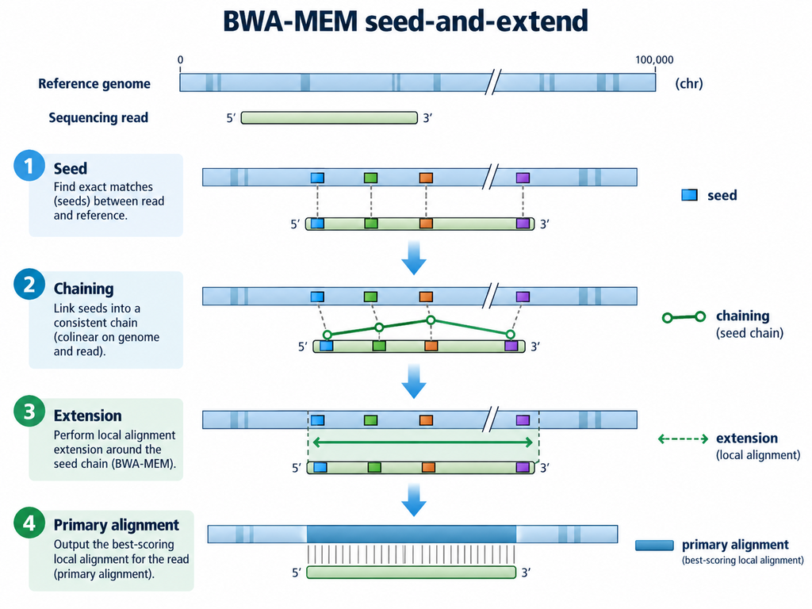

### 3.1 Alignment

For OC:

```bash
bwa mem \
  -t 8 \
  -M \
  -R "@RG\tID:OC\tPL:illumina\tSM:OC\tLB:WES_OC" \
  "$REFERENCE" \
  "$OUT/0_fastq/OC_R1.clean.fq.gz" \
  "$OUT/0_fastq/OC_R2.clean.fq.gz" \
  > "$OUT/1_alignment/OC/OC.sam"
```

For PBMC:

```bash
bwa mem \
  -t 8 \
  -M \
  -R "@RG\tID:PBMC\tPL:illumina\tSM:blood\tLB:WES_PBMC" \
  "$REFERENCE" \
  "$OUT/0_fastq/PBMC_R1.clean.fq.gz" \
  "$OUT/0_fastq/PBMC_R2.clean.fq.gz" \
  > "$OUT/1_alignment/PBMC/blood.sam"
```

The read group is important:

| Field | Meaning |
| --- | --- |
| `ID` | Unique read-group identifier |
| `PL` | Sequencing platform |
| `SM` | Sample name |
| `LB` | DNA library name |

The sample name `SM` must be correct. GATK uses it to distinguish samples during joint genotyping or tumor-normal calling.

### 3.2 SAM to BAM

SAM is text; BAM is binary. BAM is smaller and faster for software to read.

```bash
samtools view -bS -@ 8 \
  "$OUT/1_alignment/OC/OC.sam" \
  > "$OUT/1_alignment/OC/OC.bam"

samtools view -bS -@ 8 \
  "$OUT/1_alignment/PBMC/blood.sam" \
  > "$OUT/1_alignment/PBMC/blood.bam"
```

### 3.3 Sort and index BAM

Variant callers require coordinate-sorted BAM files.

```bash
samtools sort -@ 8 -m 4G \
  "$OUT/1_alignment/OC/OC.bam" \
  -o "$OUT/1_alignment/OC/OC_sorted.bam"

samtools sort -@ 8 -m 4G \
  "$OUT/1_alignment/PBMC/blood.bam" \
  -o "$OUT/1_alignment/PBMC/blood_sorted.bam"

samtools index -@ 8 "$OUT/1_alignment/OC/OC_sorted.bam"
samtools index -@ 8 "$OUT/1_alignment/PBMC/blood_sorted.bam"
```

### 3.4 Alignment metrics

```bash
samtools flagstat -@ 8 "$OUT/1_alignment/OC/OC_sorted.bam" \
  > "$OUT/1_alignment/OC/OC.flagstat.txt"

samtools flagstat -@ 8 "$OUT/1_alignment/PBMC/blood_sorted.bam" \
  > "$OUT/1_alignment/PBMC/blood.flagstat.txt"
```

Key metrics:

| Metric | Desired pattern |
| --- | --- |
| Mapped reads | Usually >95% for WES |
| Properly paired | High, typically >90% |
| Duplicate rate | Library-dependent, should not be extreme |
| Mismatch rate | Should be low after QC |

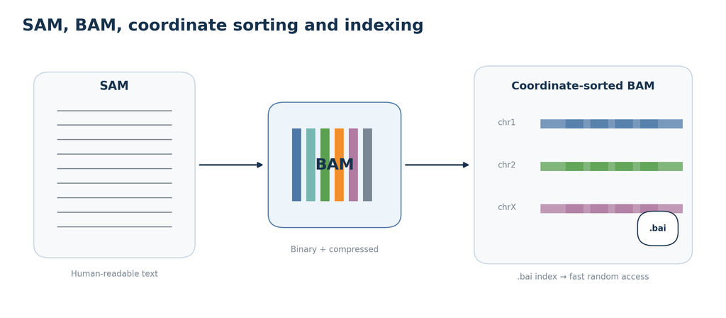

## 4. Mark PCR duplicates

Duplicate read pairs often arise from PCR amplification of the same original DNA fragment. If the same fragment is sequenced many times, those reads are not independent observations. Treating them as independent can inflate confidence in a variant.

GATK `MarkDuplicates` identifies duplicate read pairs primarily by:

1. Unclipped alignment start.
2. Unclipped alignment end.
3. Read-pair orientation.
4. Mate position.

It then marks all but one read pair as duplicates. The representative read is chosen using base quality and other criteria. The BAM records are not usually removed; they are flagged.

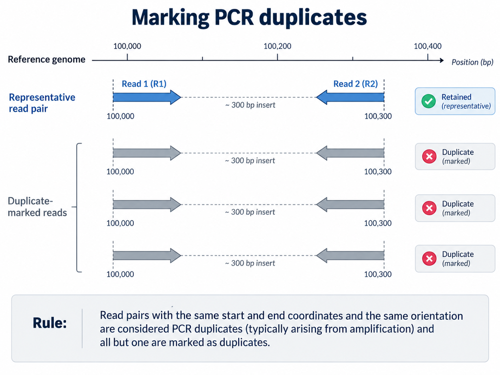

### 4.1 Mark duplicates

For OC:

```bash
gatk --java-options "-Xmx8g" MarkDuplicates \
  -I "$OUT/1_alignment/OC/OC_sorted.bam" \
  -O "$OUT/1_alignment/OC/OC_sorted.markdup.bam" \
  -M "$OUT/1_alignment/OC/OC_markdup_metrics.txt" \
  --CREATE_INDEX true
```

For PBMC:

```bash
gatk --java-options "-Xmx8g" MarkDuplicates \
  -I "$OUT/1_alignment/PBMC/blood_sorted.bam" \
  -O "$OUT/1_alignment/PBMC/blood_sorted.markdup.bam" \
  -M "$OUT/1_alignment/PBMC/blood_markdup_metrics.txt" \
  --CREATE_INDEX true
```

### 4.2 Inspect duplicate metrics

```bash
grep -A 6 '^LIBRARY' "$OUT/1_alignment/OC/OC_markdup_metrics.txt"
```

Important columns:

| Column | Meaning |
| --- | --- |
| `READ_PAIRS_EXAMINED` | Number of read pairs used for duplicate analysis |
| `READ_PAIR_DUPLICATES` | Duplicate read pairs |
| `PERCENT_DUPLICATION` | Fraction of data marked as duplicates |

## 5. Base quality score recalibration

FASTQ quality scores are the sequencer's initial estimates of per-base error probability. These estimates can be systematically biased by sequencing chemistry, cycle, read position, and sequence context.

BQSR does not change the called bases. It changes how much the caller trusts each base.

The algorithm uses known polymorphic sites to distinguish real variation from technical error. It then models systematic errors using covariates such as:

```
read group
quality score
machine cycle
sequence context
```

For a base with reported quality `Q_reported`, the empirical error rate among similar bases is used to infer an adjusted quality `Q_adjusted`.

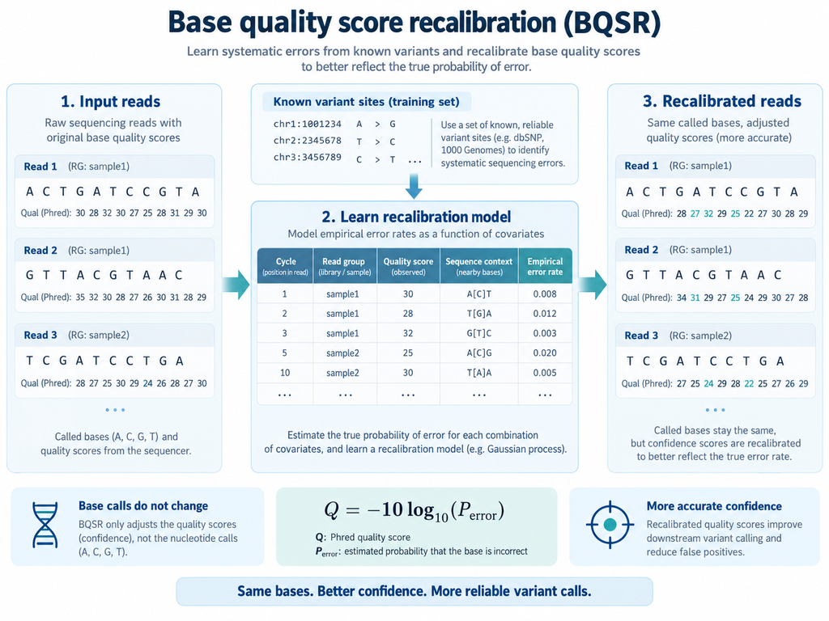

### 5.1 Learn the recalibration model

```bash
gatk --java-options "-Xmx20g -XX:ParallelGCThreads=4" BaseRecalibrator \
  -R "$REFERENCE" \
  -I "$OUT/1_alignment/OC/OC_sorted.markdup.bam" \
  --known-sites "$DBSNP" \
  --known-sites "$INDELS" \
  --known-sites "$HIGHCONF" \
  -O "$OUT/1_alignment/OC/OC.recal_data.table"

gatk --java-options "-Xmx20g -XX:ParallelGCThreads=4" BaseRecalibrator \
  -R "$REFERENCE" \
  -I "$OUT/1_alignment/PBMC/blood_sorted.markdup.bam" \
  --known-sites "$DBSNP" \
  --known-sites "$INDELS" \
  --known-sites "$HIGHCONF" \
  -O "$OUT/1_alignment/PBMC/blood.recal_data.table"
```

Resource roles:

| Resource | Use in BQSR |
| --- | --- |
| dbSNP | Known variant sites; excluded from error estimation |
| Mills/1000G indels | High-confidence indel truth sites |
| 1000G high-confidence SNPs | High-confidence SNP truth sites |

### 5.2 Apply recalibration

```bash
gatk --java-options "-Xmx12g -XX:ParallelGCThreads=4" ApplyBQSR \
  -R "$REFERENCE" \
  -I "$OUT/1_alignment/OC/OC_sorted.markdup.bam" \
  --bqsr-recal-file "$OUT/1_alignment/OC/OC.recal_data.table" \
  -O "$OUT/1_alignment/OC/OC_sorted.markdup.BQSR.bam"

gatk --java-options "-Xmx12g -XX:ParallelGCThreads=4" ApplyBQSR \
  -R "$REFERENCE" \
  -I "$OUT/1_alignment/PBMC/blood_sorted.markdup.bam" \
  --bqsr-recal-file "$OUT/1_alignment/PBMC/blood.recal_data.table" \
  -O "$OUT/1_alignment/PBMC/blood_sorted.markdup.BQSR.bam"
```

## 6. Germline variant calling

> "The purpose of computing is insight, not numbers."  
> — Richard Hamming

The main short variants are:

| Variant type | Definition |
| --- | --- |
| SNP | Single-nucleotide polymorphism |
| SNV | Single-nucleotide variant relative to reference |
| Insertion | Added sequence relative to reference |
| Deletion | Missing sequence relative to reference |
| MNP | Multiple adjacent substituted bases |

### 6.1 HaplotypeCaller algorithm

GATK HaplotypeCaller is not a pileup-only caller. Its key idea is local haplotype reconstruction:

1. Identify active regions with variation evidence.
2. Locally reassemble reads into candidate haplotypes.
3. Build a de Bruijn-like graph from k-mers.
4. Align candidate haplotypes to the reference.
5. Use PairHMM to compute read-haplotype likelihoods.
6. Use Bayesian genotype likelihoods to choose the most likely genotype.

PairHMM handles alignment uncertainty, especially near indels and homopolymers.

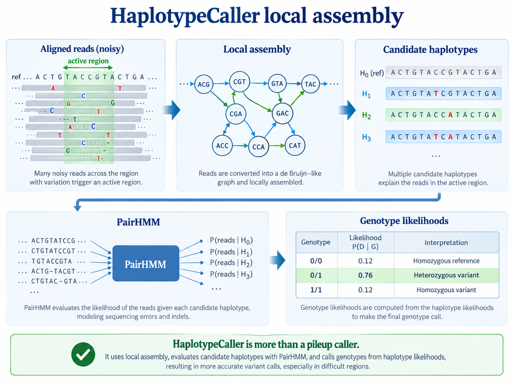

### 6.2 Call GVCFs

For OC:

```bash
gatk --java-options "-Xmx12g -XX:ParallelGCThreads=4" HaplotypeCaller \
  -ERC GVCF \
  -R "$REFERENCE" \
  -I "$OUT/1_alignment/OC/OC_sorted.markdup.BQSR.bam" \
  -D "$DBSNP" \
  -L "$TARGETS" \
  --native-pair-hmm-threads 8 \
  -O "$OUT/1_alignment/OC/OC.g.vcf"
```

For PBMC:

```bash
gatk --java-options "-Xmx12g -XX:ParallelGCThreads=4" HaplotypeCaller \
  -ERC GVCF \
  -R "$REFERENCE" \
  -I "$OUT/1_alignment/PBMC/blood_sorted.markdup.BQSR.bam" \
  -D "$DBSNP" \
  -L "$TARGETS" \
  --native-pair-hmm-threads 8 \
  -O "$OUT/1_alignment/PBMC/blood.g.vcf"
```

GVCF output includes both variant sites and confident hom-ref sites, which is useful for joint genotyping.

### 6.3 Combine and genotype GVCFs

```bash
gatk --java-options "-Xmx16g -XX:ParallelGCThreads=4" CombineGVCFs \
  -R "$REFERENCE" \
  -V "$OUT/1_alignment/OC/OC.g.vcf" \
  -V "$OUT/1_alignment/PBMC/blood.g.vcf" \
  -O "$OUT/2_variant_call/combined.g.vcf"

gatk --java-options "-Xmx16g -XX:ParallelGCThreads=4" GenotypeGVCFs \
  -R "$REFERENCE" \
  -V "$OUT/2_variant_call/combined.g.vcf" \
  -D "$DBSNP" \
  -O "$OUT/2_variant_call/OC_blood_variants.vcf"
```

### 6.4 VariantAnnotator

Some teaching workflows explicitly run VariantAnnotator before VQSR:

```bash
gatk --java-options "-Xmx12g -XX:ParallelGCThreads=4" VariantAnnotator \
  -R "$REFERENCE" \
  -I "$OUT/1_alignment/OC/OC_sorted.markdup.BQSR.bam" \
  -V "$OUT/2_variant_call/OC_blood_variants.vcf" \
  -D "$DBSNP" \
  -O "$OUT/2_variant_call/OC_blood_variants.anno.vcf"
```

In newer GATK4 workflows, HaplotypeCaller already emits many annotations, so this step may be redundant.

### 6.5 VCF format

A VCF record has eight mandatory columns:

```
CHROM POS ID REF ALT QUAL FILTER INFO
```

After genotype columns, the common FORMAT fields are:

| Field | Meaning |
| --- | --- |
| `GT` | Genotype, e.g. `0/0`, `0/1`, `1/1` |
| `AD` | Allelic depth for reference and alternate alleles |
| `DP` | Total depth |
| `GQ` | Genotype quality |
| `PL` | Phred-scaled likelihoods for possible genotypes |

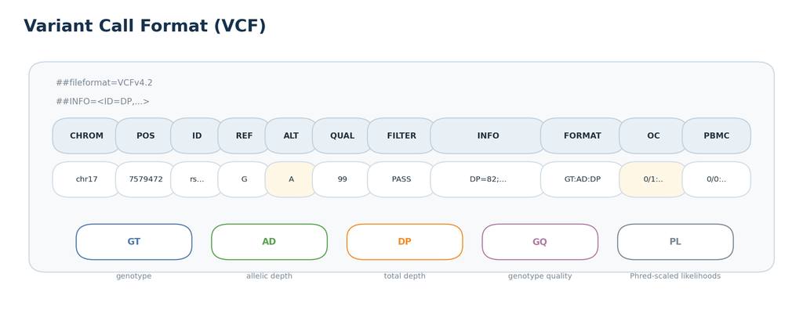

## 7. Variant quality score recalibration

> "All models are wrong, but some are useful."  
> — George E. P. Box

VQSR learns what true variants and likely artifacts look like in annotation space.

For SNPs, typical annotations are:

| Annotation | Intuition |
| --- | --- |
| `QD` | Variant confidence divided by depth |
| `MQ` | Mapping quality |
| `MQRankSum` | Mapping-quality difference between alt and ref reads |
| `ReadPosRankSum` | Alt-vs-ref read-position bias |
| `FS` | Fisher strand bias |
| `SOR` | Symmetric odds ratio strand bias |

For indels, GATK often uses a smaller annotation set such as `QD`, `ReadPosRankSum`, `FS`, and `SOR`.

The VariantRecalibrator fits a Gaussian mixture model:

1. High-confidence truth resources define likely true variants.
2. Known but non-truth resources define known variants.
3. Novel variants are treated as possible false positives.
4. The model scores each variant by similarity to true variation.
5. Tranches define sensitivity levels, for example 99.5% SNP truth sensitivity.

ApplyVQSR labels variants as `PASS` or filtered according to the chosen tranche.

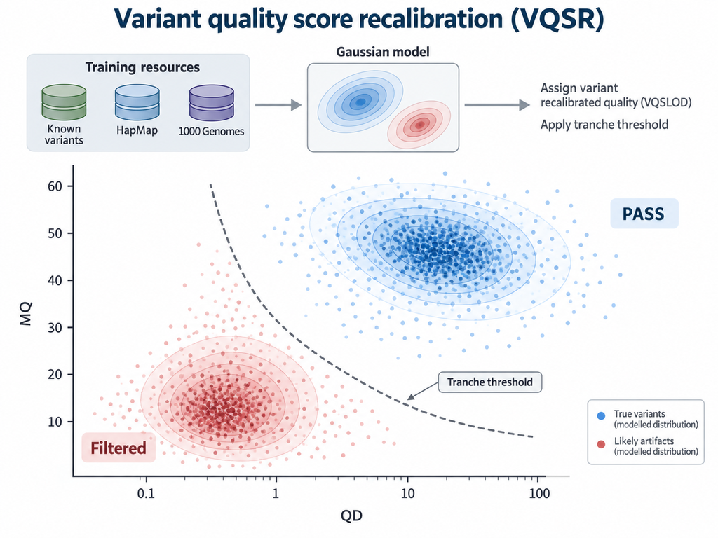

### 7.1 SNP VQSR

```bash
gatk --java-options "-Xmx20g -XX:ParallelGCThreads=4" VariantRecalibrator \
  -R "$REFERENCE" \
  -V "$OUT/2_variant_call/OC_blood_variants.vcf" \
  --resource:hapmap,known=false,training=true,truth=true,prior=15.0 "$HAPMAP" \
  --resource:omni,known=false,training=true,truth=false,prior=12.0 "$OMNI" \
  --resource:1000G,known=false,training=true,truth=false,prior=10.0 "$HIGHCONF" \
  --resource:dbsnp,known=true,training=false,truth=false,prior=2.0 "$DBSNP" \
  -an QD -an MQ -an MQRankSum -an ReadPosRankSum -an FS -an SOR \
  -mode SNP \
  -O "$OUT/2_variant_call/OC_blood.snps.recal" \
  --tranches-file "$OUT/2_variant_call/OC_blood.snps.tranches" \
  --rscript-file "$OUT/2_variant_call/OC_blood.snps.plots.R" \
  --dont-run-rscript

gatk --java-options "-Xmx16g -XX:ParallelGCThreads=4" ApplyVQSR \
  -R "$REFERENCE" \
  -V "$OUT/2_variant_call/OC_blood_variants.vcf" \
  -O "$OUT/2_variant_call/OC_blood.snps.VQSR.vcf" \
  --truth-sensitivity-filter-level 99.5 \
  --tranches-file "$OUT/2_variant_call/OC_blood.snps.tranches" \
  --recal-file "$OUT/2_variant_call/OC_blood.snps.recal" \
  --mode SNP
```

### 7.2 INDEL VQSR

```bash
gatk --java-options "-Xmx20g -XX:ParallelGCThreads=4" VariantRecalibrator \
  -R "$REFERENCE" \
  -V "$OUT/2_variant_call/OC_blood_variants.vcf" \
  --resource:mills,known=false,training=true,truth=true,prior=12.0 "$INDELS" \
  --resource:dbsnp,known=true,training=false,truth=false,prior=2.0 "$DBSNP" \
  -an QD -an ReadPosRankSum -an FS -an SOR \
  -mode INDEL \
  --max-gaussians 4 \
  -O "$OUT/2_variant_call/OC_blood.indel.recal" \
  --tranches-file "$OUT/2_variant_call/OC_blood.indel.tranches" \
  --rscript-file "$OUT/2_variant_call/OC_blood.indel.plots.R" \
  --dont-run-rscript

gatk --java-options "-Xmx16g -XX:ParallelGCThreads=4" ApplyVQSR \
  -R "$REFERENCE" \
  -V "$OUT/2_variant_call/OC_blood_variants.vcf" \
  -O "$OUT/2_variant_call/OC_blood.indel.VQSR.vcf" \
  --truth-sensitivity-filter-level 99.0 \
  --tranches-file "$OUT/2_variant_call/OC_blood.indel.tranches" \
  --recal-file "$OUT/2_variant_call/OC_blood.indel.recal" \
  --mode INDEL
```

### 7.3 Merge SNP and indel outputs

```bash
gatk --java-options "-Xmx12g -XX:ParallelGCThreads=4" MergeVcfs \
  -O "$OUT/2_variant_call/OC_blood.all.VQSR.vcf" \
  -I "$OUT/2_variant_call/OC_blood.indel.VQSR.vcf" \
  -I "$OUT/2_variant_call/OC_blood.snps.VQSR.vcf"
```

Count PASS variants:

```bash
bcftools view -H -f PASS "$OUT/2_variant_call/OC_blood.all.VQSR.vcf" | wc -l
```

## 8. Functional annotation with ANNOVAR

> "Somewhere, something incredible is waiting to be known."  
> — Carl Sagan

VQSR tells us whether a variant is likely real. ANNOVAR tells us what it may do.

ANNOVAR can annotate:

1. Gene and exon/intron/intergenic location.
2. Coding effect: synonymous, nonsynonymous, stopgain, stoploss, frameshift.
3. Transcript and protein change.
4. Population frequency, for example gnomAD or 1000 Genomes.
5. dbSNP identifier.
6. Clinical or functional prediction databases.

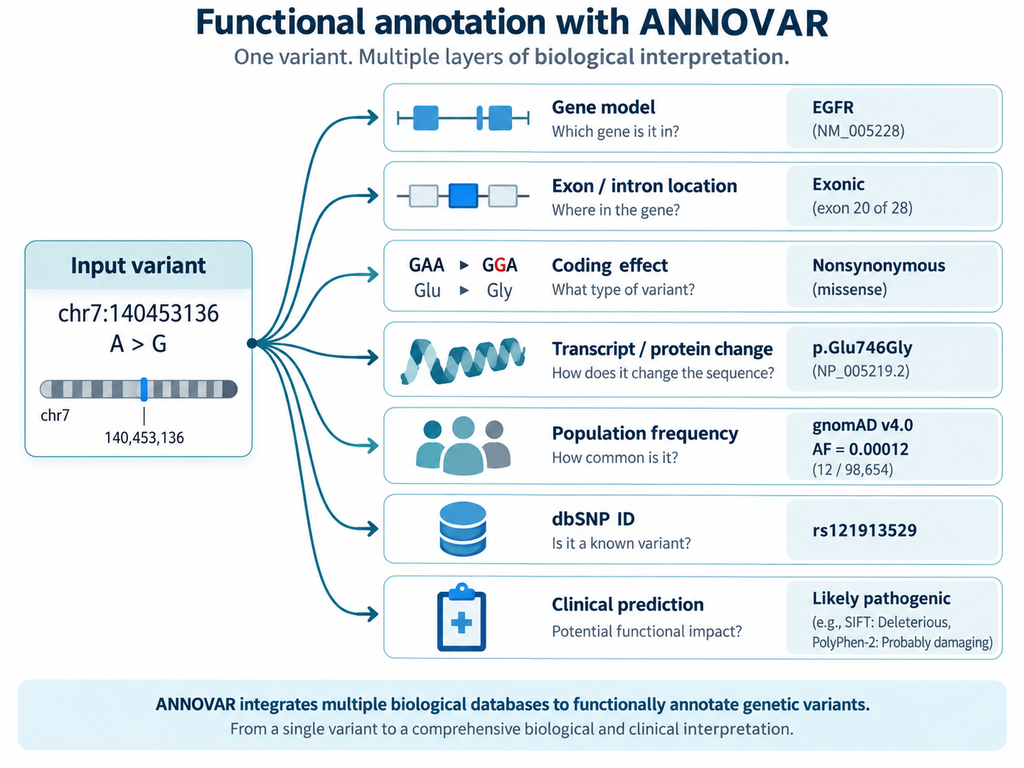

### 8.1 Convert VCF to ANNOVAR input

```bash
mkdir -p "$OUT/3_annotation"

perl "$ANNOVAR/convert2annovar.pl" \
  -format vcf4old \
  "$OUT/2_variant_call/OC_blood.all.VQSR.vcf" \
  -includeinfo \
  -comment \
  -outfile "$OUT/3_annotation/OC_blood.all.avinput"
```

### 8.2 Gene annotation

```bash
perl "$ANNOVAR/annotate_variation.pl" \
  -geneanno \
  -buildver hg38 \
  -dbtype refGeneWithVer \
  "$OUT/3_annotation/OC_blood.all.avinput" \
  "$HUMANDB"
```

### 8.3 Multi-annotation table

```bash
perl "$ANNOVAR/table_annovar.pl" \
  "$OUT/3_annotation/OC_blood.all.avinput" \
  "$HUMANDB" \
  -buildver hg38 \
  -out "$OUT/3_annotation/OC_blood_anno" \
  -remove \
  -protocol refGeneWithVer \
  -operation g
```

If frequency and prediction databases are available, a richer protocol is:

```bash
perl "$ANNOVAR/table_annovar.pl" \
  "$OUT/3_annotation/OC_blood.all.avinput" \
  "$HUMANDB" \
  -buildver hg38 \
  -out "$OUT/3_annotation/OC_blood_anno" \
  -remove \
  -protocol refGeneWithVer,cytoBand,dbnsfp30a,exac03,gnomad_genome,avsnp147 \
  -operation g,r,f,f,f,f
```

## 9. Somatic TMB using matched normal

The germline/joint VCF is not a formal somatic TMB result. Formal TMB should use tumor-normal somatic calling.

TMB is usually:

```
TMB = number of qualifying somatic variants / callable target size in megabases
```

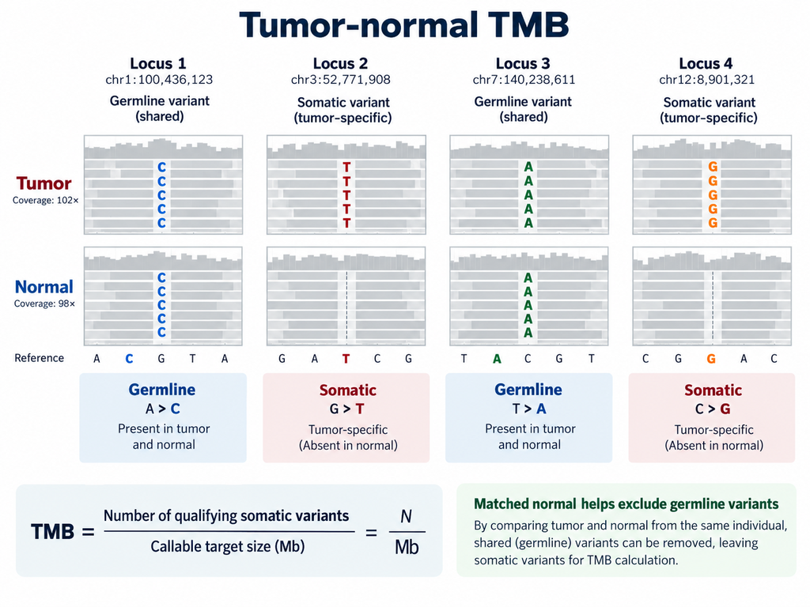

### 9.1 Mutect2 tumor-normal calling

```bash
TUMOR=$OUT/1_alignment/OC/OC_sorted.markdup.BQSR.bam
NORMAL=$OUT/1_alignment/PBMC/blood_sorted.markdup.BQSR.bam
SOMOUT=$OUT/5_somatic_tmb/
mkdir -p "$SOMOUT"

gatk --java-options "-Xmx16g -XX:ParallelGCThreads=4" Mutect2 \
  -R "$REFERENCE" \
  -I "$TUMOR" \
  -I "$NORMAL" \
  --normal-sample blood \
  -L "$TARGETS" \
  --germline-resource "$HIGHCONF" \
  -O "$SOMOUT/somatic.raw.vcf.gz" \
  --native-pair-hmm-threads 8 \
  --f1r2-tar-gz "$SOMOUT/f1r2.tar.gz"
```

### 9.2 Orientation bias model

```bash
gatk --java-options "-Xmx8g -XX:ParallelGCThreads=4" LearnReadOrientationModel \
  -I "$SOMOUT/f1r2.tar.gz" \
  -O "$SOMOUT/orientation_model.tar.gz"

gatk --java-options "-Xmx12g -XX:ParallelGCThreads=4" FilterMutectCalls \
  -R "$REFERENCE" \
  -V "$SOMOUT/somatic.raw.vcf.gz" \
  --stats "$SOMOUT/somatic.raw.vcf.gz.stats" \
  --ob-priors "$SOMOUT/orientation_model.tar.gz" \
  -O "$SOMOUT/somatic.filtered.vcf.gz"

bcftools view -f PASS \
  -Oz \
  -o "$SOMOUT/somatic.pass.vcf.gz" \
  "$SOMOUT/somatic.filtered.vcf.gz"

bcftools index -t "$SOMOUT/somatic.pass.vcf.gz"
```

### 9.3 Compute TMB

```bash
TARGET_SIZE_MB=$(awk 'BEGIN{FS="\t"} {sum += ($3 - $2)} END {printf "%.6f", sum / 1000000}' "$TARGETS")
PASS_VARIANTS=$(bcftools view -H -f PASS "$SOMOUT/somatic.filtered.vcf.gz" | wc -l)

awk -v n="$PASS_VARIANTS" -v mb="$TARGET_SIZE_MB" \
  'BEGIN {printf "somatic TMB = %.6f variants/Mb\n", n / mb}'
```

> **Take-home question**: Why we don't use the joint VCF we generated in 7.3 for TMB calculation? What is the difference between these two variants?

## 10. CNV detection with CNVkit

CNVkit detects copy-number changes using binned read depth. In WES, target bins correspond to capture intervals. In hybrid capture mode, off-target bins can also be used; in amplicon mode, only target bins are used.

The CNVkit logic is:

1. Divide the genome or target space into bins.
2. Compute depth per bin in tumor and normal.
3. Normalize tumor depth against normal depth and systematic biases.
4. Calculate a log2 ratio per bin.
5. Merge neighboring bins into segments.
6. Convert segment log2 ratios into integer copy numbers.

The default CNVkit segmentation method is CBS, circular binary segmentation. CBS tests whether adjacent bins should be split into two segments with different mean log2 ratios.

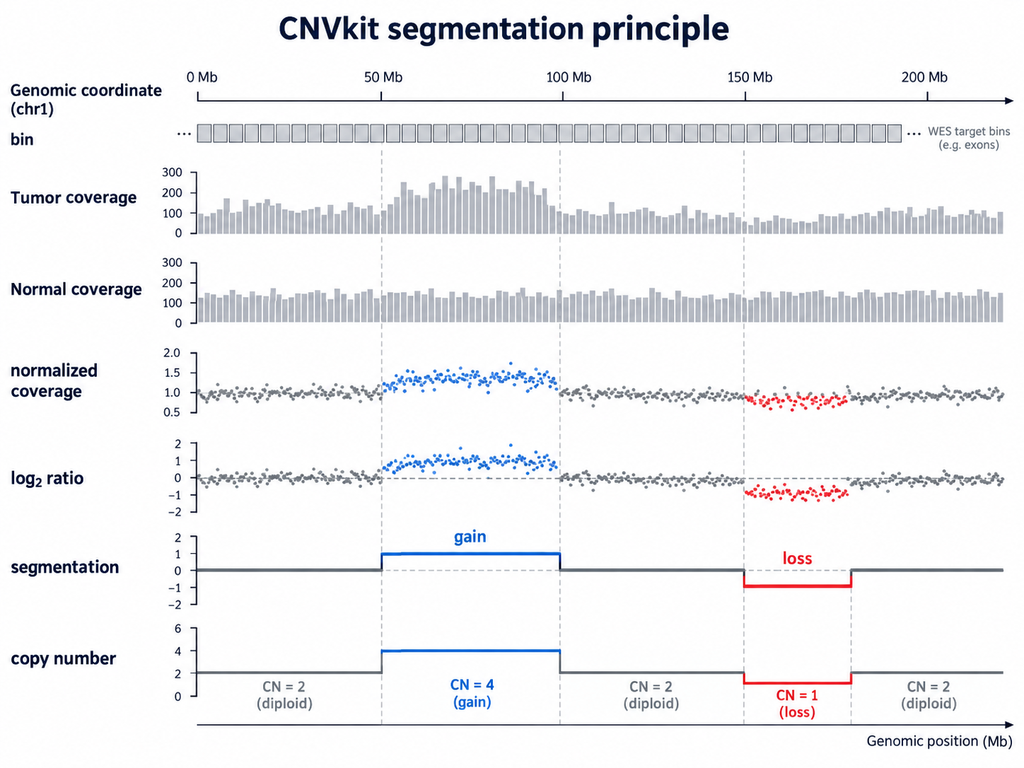

### 10.1 Prepare target BED

```bash
CNVOUT=$OUT/4_cnv
mkdir -p "$CNVOUT"
ln -s "$TARGETS" "$CNVOUT/targets.bed"
```

### 10.2 Run CNVkit batch

```bash
cnvkit.py batch \
  "$TUMOR" \
  -n "$NORMAL" \
  -f "$REFERENCE" \
  -t "$CNVOUT/targets.bed" \
  -m amplicon \
  --output-reference "$CNVOUT/reference.cnn" \
  -d "$CNVOUT/cnvkit_out" \
  --scatter \
  --diagram \
  -p 8
```

Important outputs:

| File | Level | Meaning |
| --- | --- | --- |
| `.cnr` | bin | Normalized bin-level log2 ratios |
| `.cns` | segment | Segmented log2 ratios |
| `.call.cns` | segment | Absolute copy-number calls |
| `scatter.png` | genome | Genome-wide log2 ratio plot |
| `diagram.pdf` | chromosome | Chromosome-level CNV summary |

### 10.3 Interpret `.call.cns`

Key columns:

```
chromosome start end gene log2 cn depth p_ttest probes weight
```

Interpretation:

| Column | Meaning |
| --- | --- |
| `log2` | Normalized segment log2 ratio |
| `cn` | Called integer copy number |
| `probes` | Number of supporting bins |
| `weight` | Segment confidence |
| `p_ttest` | Statistical significance of the segment |

The `gene` column is inherited from the fourth BED column. The shared target BED has only chromosome, start, and end columns, so map intervals to genes before making gene-level claims; do not treat this column as a normalized gene-name list.

## 11. Interpretation checklist

Before interpreting a WES result, check:

1. Is the reference genome consistent across all resources?
2. Are sample names correct in read groups?
3. Are BAMs coordinate-sorted and indexed?
4. Are duplicate metrics reasonable?
5. Is coverage sufficient over the capture targets?
6. Does the callset contain a plausible Ti/Tv ratio?
7. Are VQSR resources in the same genome build?
8. For TMB, was a matched normal used?
9. Are annotations in the same transcript and genome version?

## 12. File summary

[output not shown]

## 13. Summary

> "Progress in science depends on new techniques, new discoveries and new ideas, probably in that order."  
> — Sydney Brenner

WES analysis converts uncertain sequencing observations into increasingly interpretable biological statements: first reads become alignments, alignments become variants, variants become statistically filtered calls, and calls finally become annotated biological hypotheses. Whole-exome sequencing gives us a practical way to read one of the most information-rich parts of that book—the protein-coding exome, and so we can say: we celebrate the revelation of the draft of the human book of life.

Any questions are welcome and please contact me at `jiahaoma@stu.pku.edu.cn`.

> “纸上得来终觉浅，绝知此事要躬行。”